# IRF

Michiel van Eldik

10/13/2020

Once we have specified our dynamic model system. Nice! That’s really the heart of what we do. We can now start with making our **estimations**. These can be used to make **policy decisions**. However, we have included so many parameters, that it may be nearly impossible to interpret all parameters.

- **Exogeneous** is actually really straight forward
- **Endogeneous** is not so straight-forward

If you have this whole system of feedback and lags, it’s almost impossible to get what’s going on.

## **IRF in practise**

The basic idea is that * We apply a “shock” to one of the series (e.g., advertising) * We trace the effect of this shock through the system on each of the other series (sales, price, competitor advertising, etc.) The we calculate between **two series**: * One benchmark series where nothing happens * One shock series where the shock is applied.

```
= calculate the difference between these two series.
```

What happens to our system if I apply the shock, what happens if I don’t do it? What is the additional sales due to the shock in sales?

### **When variables are stationary**

If you have stationary variables…

No lasting effects of our shocks. Series return to it’s pre-shock level.

Effects to analyse: * Immediate effect * Cumulative effect (in this case interesting as there is no permanent effect) i.e., what is the **full effect overall** * Permanent effec = 0

### **When variables are non-stationary**

If you have evolving variables…

Effects do not die over time. Series may not return back!

```
* Immediate effect
```

## **Restricted IRF**

Standard situation: Estimate a full VAR/VEC without parameter restrictions. **All endogeneous variables are allowed to affect each other at every single lag** But how to observe the relative contribution of different variables to the final outcome observed?

Solution: Compare the restricted IRF with the full IRF to get insight on the relative contribution.

E.g., Trace the effect of advertising on sales, while keeping competitor variables constant. What is the pure effect of our advertising, without any competitor reaction effects?

## **Generalized IRF**

With the restricted IRF, you have to specify logic yourself. You impose the order yourself: Advertising, performance, satisfaction. That might have an effect. BUT **sometimes the ordering is not clear**.

There are all kinds of metrics like online purchase-funnel behaviour, online metrics, etc.

That’s where we get the idea of **Generalized IRF** = calculate the immediate effect from the variance-covariance matrix.

Standard R packages don’t exist for this.

## **Case**

```r
library(lmtest)
library(vars)
library(aTSA)
railways.df <-read.csv("../SLIM0607Railways.csv")
```

```r
#Determining lag length of the endogenous variables
railendo = railways.df[,c(3,2,5)]
railexo = railways.df[,c(11,7,8,13,9,10)]    #The trend does not have to be added here, as it can be immediately added through type "both"
VARselect(railendo,lag.max = 4, type = "both", exogen = railexo)
```

```
## $selection
## AIC(n)  HQ(n)  SC(n) FPE(n)
##      4      4      1      1
##
## $criteria
##                    1             2             3             4
## AIC(n) -2.221904e+01 -2.218911e+01 -2.262995e+01 -2.279395e+01
## HQ(n)  -2.177279e+01 -2.162116e+01 -2.194030e+01 -2.198259e+01
## SC(n)  -2.061012e+01 -2.014140e+01 -2.014345e+01 -1.986865e+01
## FPE(n)  2.718819e-10  3.574187e-10  3.634898e-10  7.565338e-10
```

```r
#Estimating the VAR model, and reporting results for the individual equations
railest <- VAR(railendo, p=1, type = "both", exogen = railexo)

# Pass-based variable
summary(railest,"LNKMABOFIX2")
```

```
##
## VAR Estimation Results:
## =========================
## Endogenous variables: LNKMLOSFIX2, LNKMABOFIX2, DLNAOAVERAGE_2L
## Deterministic variables: both
## Sample size: 28
## Log Likelihood: 226.071
## Roots of the characteristic polynomial:
## 0.6123 0.6123 0.4479
## Call:
## VAR(y = railendo, p = 1, type = "both", exogen = railexo)
##
##
## Estimation results for equation LNKMABOFIX2:
## ============================================
## LNKMABOFIX2 = LNKMLOSFIX2.l1 + LNKMABOFIX2.l1 + DLNAOAVERAGE_2L.l1 + const + trend + LNADSTOCK + RETPROMO + OWNPROMO + LNFUELPRICE + MCOS + MSIN
##
##                     Estimate Std. Error t value Pr(>|t|)
## LNKMLOSFIX2.l1     -1.245111   0.427380  -2.913  0.00968 **
## LNKMABOFIX2.l1     -0.594700   0.183970  -3.233  0.00489 **
## DLNAOAVERAGE_2L.l1 -4.555171   2.059350  -2.212  0.04095 *
## const              55.525353   9.745857   5.697 2.62e-05 ***
## trend               0.005630   0.002291   2.458  0.02500 *
## LNADSTOCK           0.072129   0.034838   2.070  0.05396 .
## RETPROMO            0.012580   0.042223   0.298  0.76936
## OWNPROMO            0.198870   0.054635   3.640  0.00203 **
## LNFUELPRICE        -0.014210   0.111517  -0.127  0.90010
## MCOS                0.110599   0.030204   3.662  0.00193 **
## MSIN                0.049608   0.029445   1.685  0.11031
## ---
## Signif. codes:  0 '***' 0.001 '**' 0.01 '*' 0.05 '.' 0.1 ' ' 1
##
##
## Residual standard error: 0.06502 on 17 degrees of freedom
## Multiple R-Squared: 0.6605,  Adjusted R-squared: 0.4609
## F-statistic: 3.308 on 10 and 17 DF,  p-value: 0.01462
##
##
##
## Covariance matrix of residuals:
##                 LNKMLOSFIX2 LNKMABOFIX2 DLNAOAVERAGE_2L
## LNKMLOSFIX2       5.642e-04  -2.266e-04      -1.153e-05
## LNKMABOFIX2      -2.266e-04   4.228e-03      -6.416e-05
## DLNAOAVERAGE_2L  -1.153e-05  -6.416e-05       3.868e-05
##
## Correlation matrix of residuals:
##                 LNKMLOSFIX2 LNKMABOFIX2 DLNAOAVERAGE_2L
## LNKMLOSFIX2         1.00000     -0.1467        -0.07807
## LNKMABOFIX2        -0.14674      1.0000        -0.15868
## DLNAOAVERAGE_2L    -0.07807     -0.1587         1.00000
```

```r
# Ticket-based variable
summary(railest,"LNKMLOSFIX2")
```

```
##
## VAR Estimation Results:
## =========================
## Endogenous variables: LNKMLOSFIX2, LNKMABOFIX2, DLNAOAVERAGE_2L
## Deterministic variables: both
## Sample size: 28
## Log Likelihood: 226.071
## Roots of the characteristic polynomial:
## 0.6123 0.6123 0.4479
## Call:
## VAR(y = railendo, p = 1, type = "both", exogen = railexo)
##
##
## Estimation results for equation LNKMLOSFIX2:
## ============================================
## LNKMLOSFIX2 = LNKMLOSFIX2.l1 + LNKMABOFIX2.l1 + DLNAOAVERAGE_2L.l1 + const + trend + LNADSTOCK + RETPROMO + OWNPROMO + LNFUELPRICE + MCOS + MSIN
##
##                      Estimate Std. Error t value Pr(>|t|)
## LNKMLOSFIX2.l1     -0.1583614  0.1561289  -1.014  0.32466
## LNKMABOFIX2.l1      0.0769817  0.0672073   1.145  0.26790
## DLNAOAVERAGE_2L.l1  1.7576559  0.7523144   2.336  0.03198 *
## const              21.7600026  3.5603209   6.112 1.15e-05 ***
## trend               0.0031043  0.0008368   3.710  0.00174 **
## LNADSTOCK           0.0117597  0.0127269   0.924  0.36842
## RETPROMO            0.0326545  0.0154246   2.117  0.04930 *
## OWNPROMO            0.0611828  0.0199592   3.065  0.00700 **
## LNFUELPRICE         0.0279903  0.0407389   0.687  0.50131
## MCOS                0.0164778  0.0110341   1.493  0.15367
## MSIN               -0.0234168  0.0107568  -2.177  0.04387 *
## ---
## Signif. codes:  0 '***' 0.001 '**' 0.01 '*' 0.05 '.' 0.1 ' ' 1
##
##
## Residual standard error: 0.02375 on 17 degrees of freedom
## Multiple R-Squared: 0.8469,  Adjusted R-squared: 0.7569
## F-statistic: 9.404 on 10 and 17 DF,  p-value: 3.92e-05
##
##
##
## Covariance matrix of residuals:
##                 LNKMLOSFIX2 LNKMABOFIX2 DLNAOAVERAGE_2L
## LNKMLOSFIX2       5.642e-04  -2.266e-04      -1.153e-05
## LNKMABOFIX2      -2.266e-04   4.228e-03      -6.416e-05
## DLNAOAVERAGE_2L  -1.153e-05  -6.416e-05       3.868e-05
##
## Correlation matrix of residuals:
##                 LNKMLOSFIX2 LNKMABOFIX2 DLNAOAVERAGE_2L
## LNKMLOSFIX2         1.00000     -0.1467        -0.07807
## LNKMABOFIX2        -0.14674      1.0000        -0.15868
## DLNAOAVERAGE_2L    -0.07807     -0.1587         1.00000
```

```r
# Satisfaction variable
summary(railest,"DLNAOAVERAGE_2L")
```

```
##
## VAR Estimation Results:
## =========================
## Endogenous variables: LNKMLOSFIX2, LNKMABOFIX2, DLNAOAVERAGE_2L
## Deterministic variables: both
## Sample size: 28
## Log Likelihood: 226.071
## Roots of the characteristic polynomial:
## 0.6123 0.6123 0.4479
## Call:
## VAR(y = railendo, p = 1, type = "both", exogen = railexo)
##
##
## Estimation results for equation DLNAOAVERAGE_2L:
## ================================================
## DLNAOAVERAGE_2L = LNKMLOSFIX2.l1 + LNKMABOFIX2.l1 + DLNAOAVERAGE_2L.l1 + const + trend + LNADSTOCK + RETPROMO + OWNPROMO + LNFUELPRICE + MCOS + MSIN
##
##                      Estimate Std. Error t value Pr(>|t|)
## LNKMLOSFIX2.l1     -0.0838819  0.0408776  -2.052   0.0559 .
## LNKMABOFIX2.l1      0.0166671  0.0175962   0.947   0.3568
## DLNAOAVERAGE_2L.l1 -0.3217207  0.1969706  -1.633   0.1208
## const               1.3846271  0.9321613   1.485   0.1557
## trend              -0.0001468  0.0002191  -0.670   0.5117
## LNADSTOCK           0.0012367  0.0033321   0.371   0.7151
## RETPROMO            0.0039129  0.0040385   0.969   0.3462
## OWNPROMO           -0.0129297  0.0052257  -2.474   0.0242 *
## LNFUELPRICE        -0.0015913  0.0106662  -0.149   0.8832
## MCOS               -0.0067663  0.0028890  -2.342   0.0316 *
## MSIN               -0.0016579  0.0028164  -0.589   0.5638
## ---
## Signif. codes:  0 '***' 0.001 '**' 0.01 '*' 0.05 '.' 0.1 ' ' 1
##
##
## Residual standard error: 0.006219 on 17 degrees of freedom
## Multiple R-Squared: 0.5571,  Adjusted R-squared: 0.2965
## F-statistic: 2.138 on 10 and 17 DF,  p-value: 0.08068
##
##
##
## Covariance matrix of residuals:
##                 LNKMLOSFIX2 LNKMABOFIX2 DLNAOAVERAGE_2L
## LNKMLOSFIX2       5.642e-04  -2.266e-04      -1.153e-05
## LNKMABOFIX2      -2.266e-04   4.228e-03      -6.416e-05
## DLNAOAVERAGE_2L  -1.153e-05  -6.416e-05       3.868e-05
##
## Correlation matrix of residuals:
##                 LNKMLOSFIX2 LNKMABOFIX2 DLNAOAVERAGE_2L
## LNKMLOSFIX2         1.00000     -0.1467        -0.07807
## LNKMABOFIX2        -0.14674      1.0000        -0.15868
## DLNAOAVERAGE_2L    -0.07807     -0.1587         1.00000
```

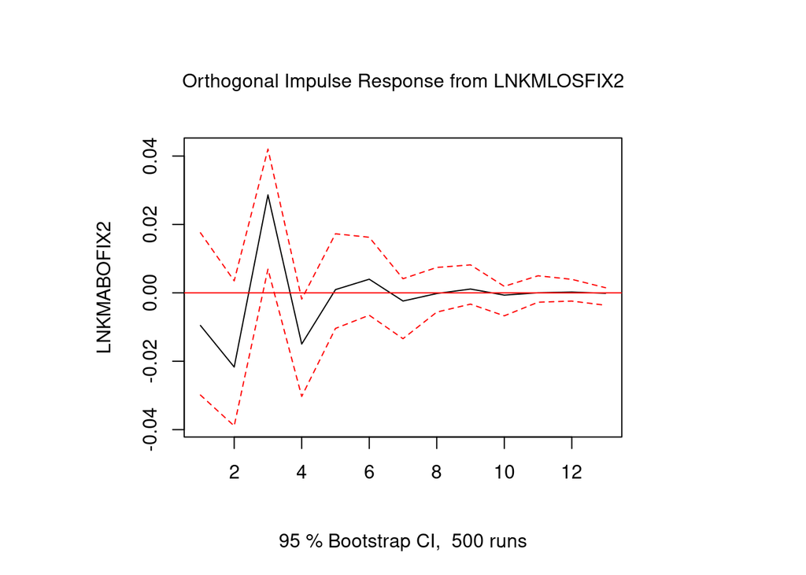

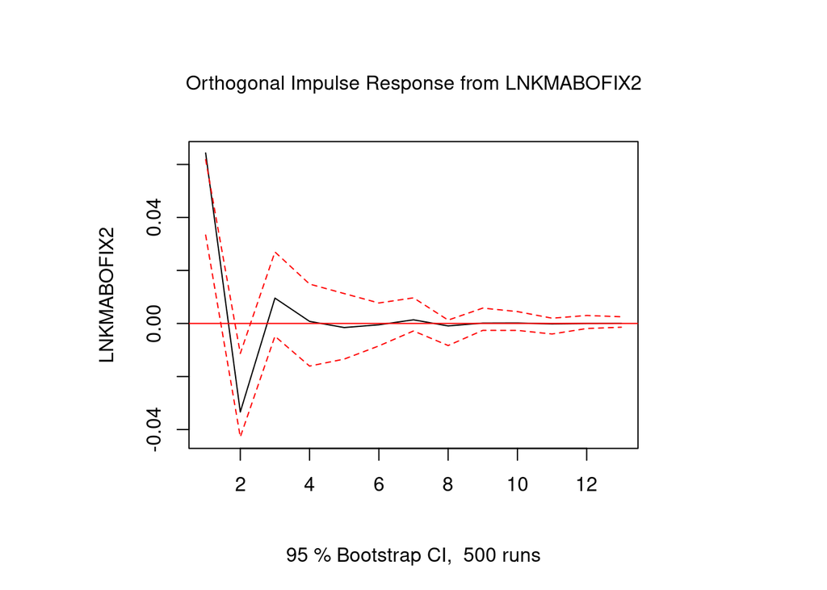

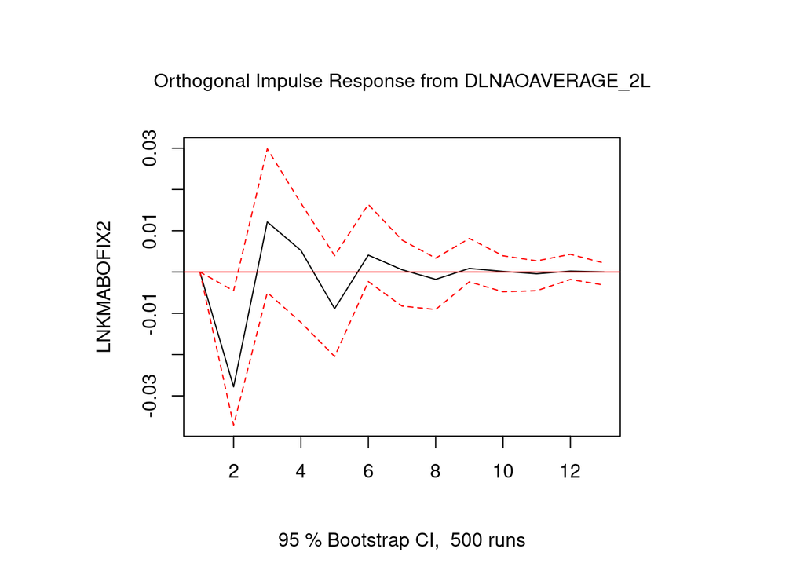

```r
#Generating the IRFs
railirf1 <- irf(railest, impulse = NULL, response = "LNKMABOFIX2", n.ahead = 12,
               ortho = TRUE, cumulative = FALSE, boot = TRUE, ci = 0.95,
               runs = 500)
plot(railirf1)
```

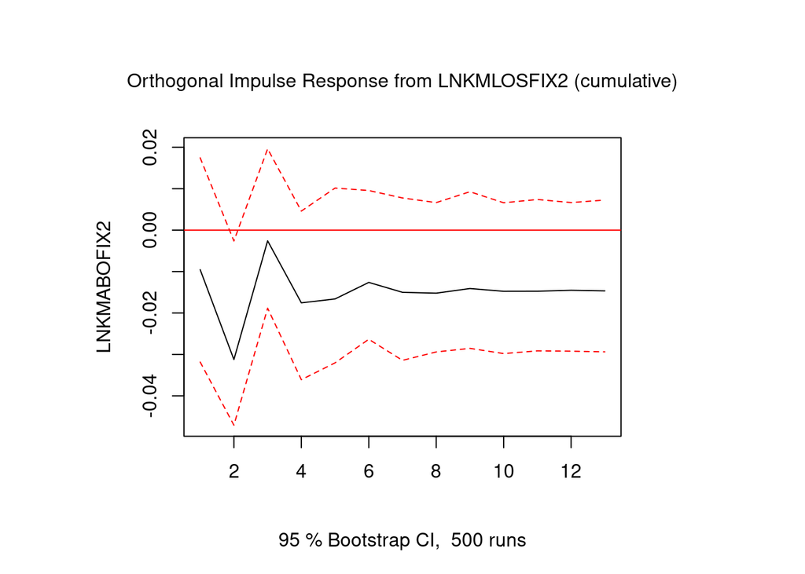

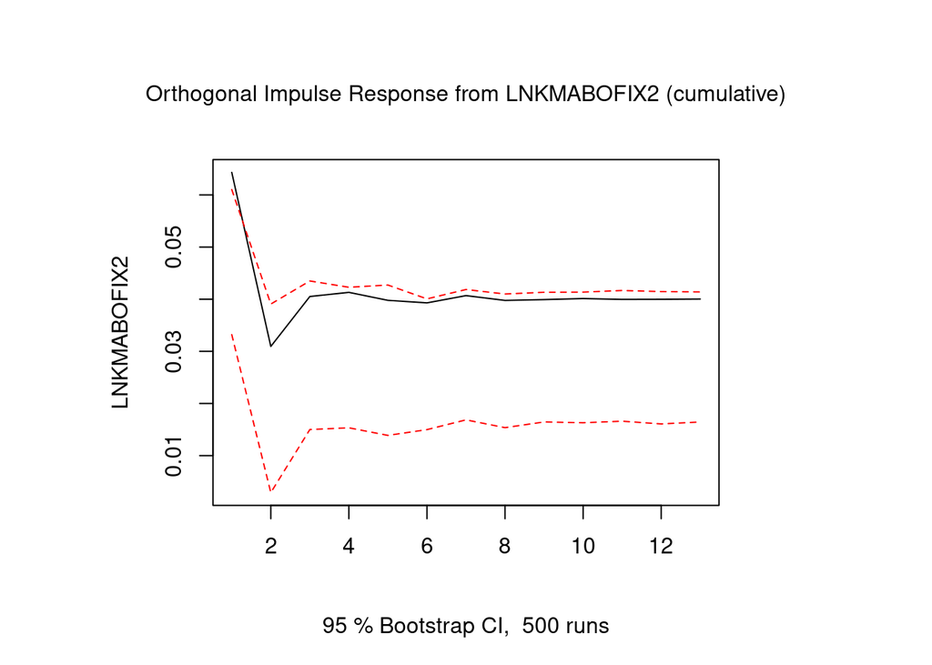

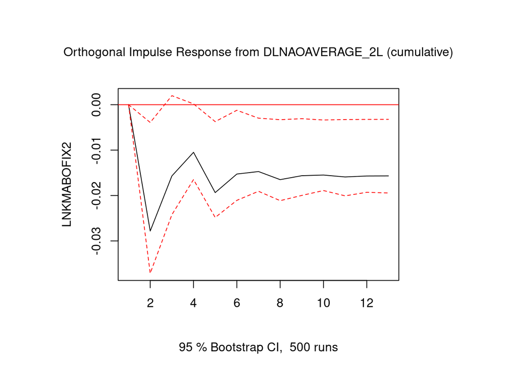

```r
railirf2 <- irf(railest, impulse = NULL, response = "LNKMABOFIX2", n.ahead = 12,
               ortho = TRUE, cumulative = TRUE, boot = TRUE, ci = 0.95,
               runs = 500)
plot(railirf2)
```

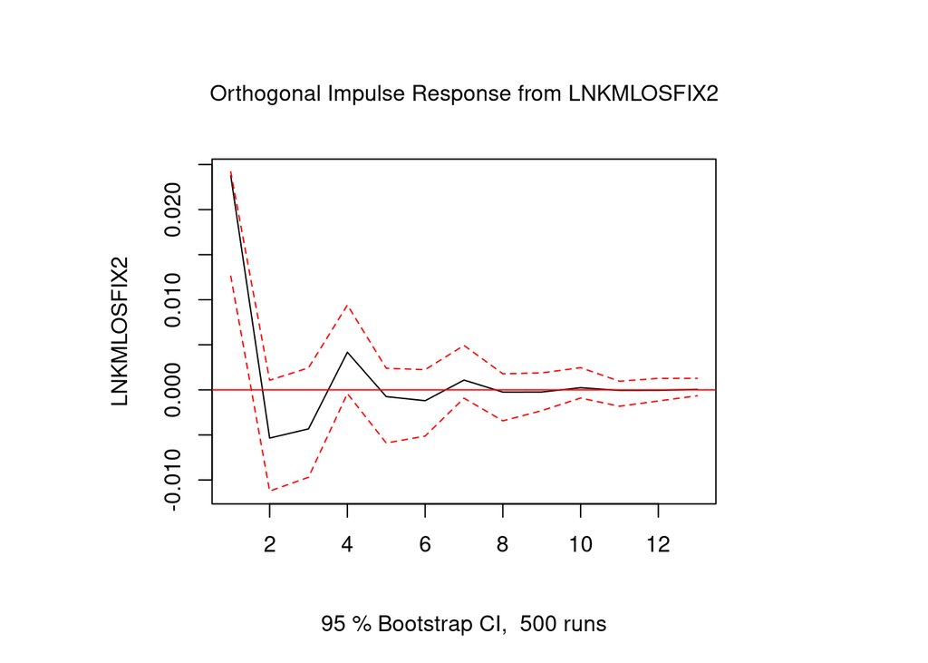

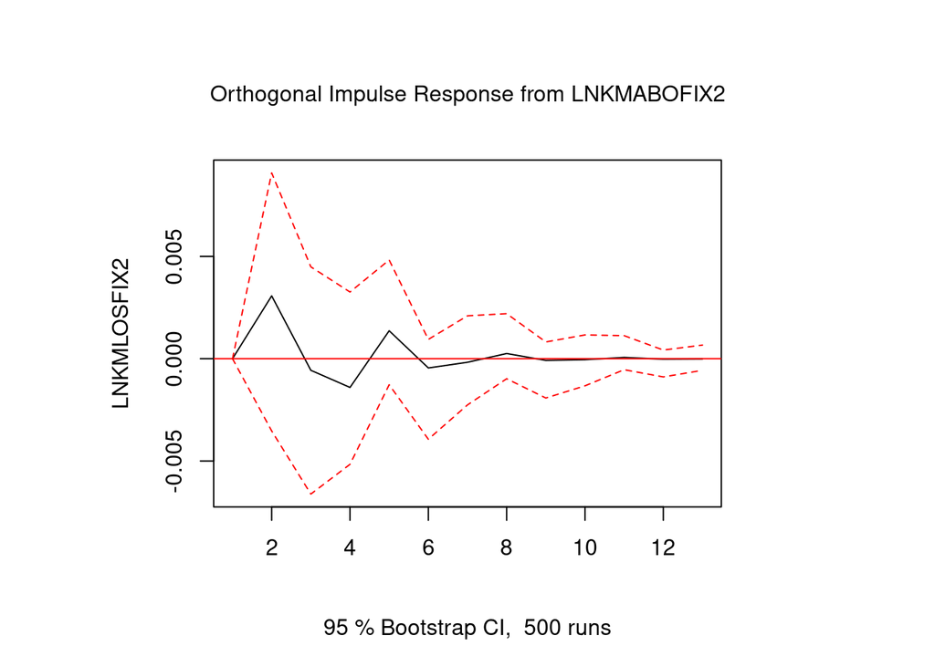

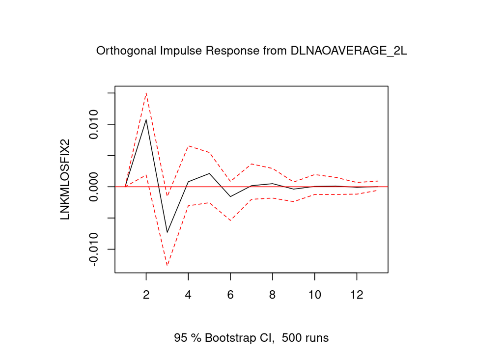

```r
railirf3 <- irf(railest, impulse = NULL, response = "LNKMLOSFIX2", n.ahead = 12,
               ortho = TRUE, cumulative = FALSE, boot = TRUE, ci = 0.95,
               runs = 500)
plot(railirf3)
```

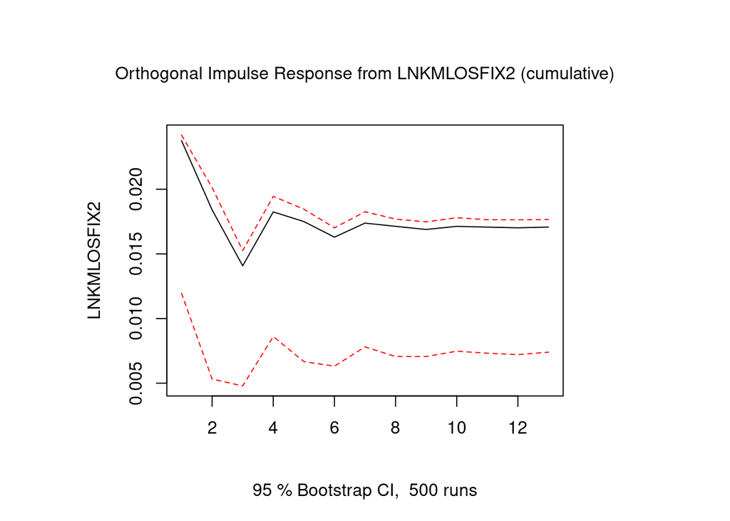

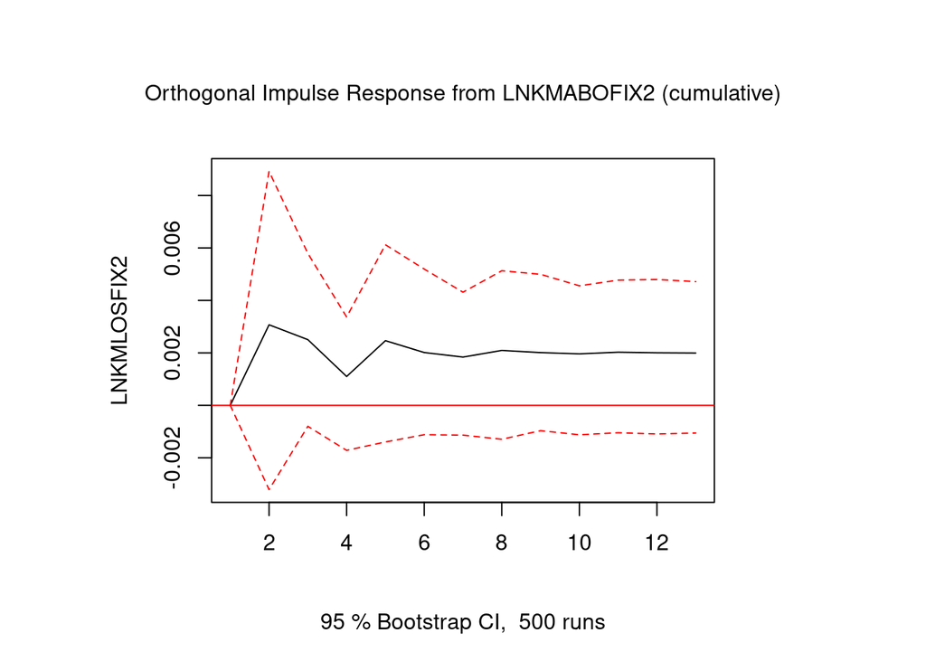

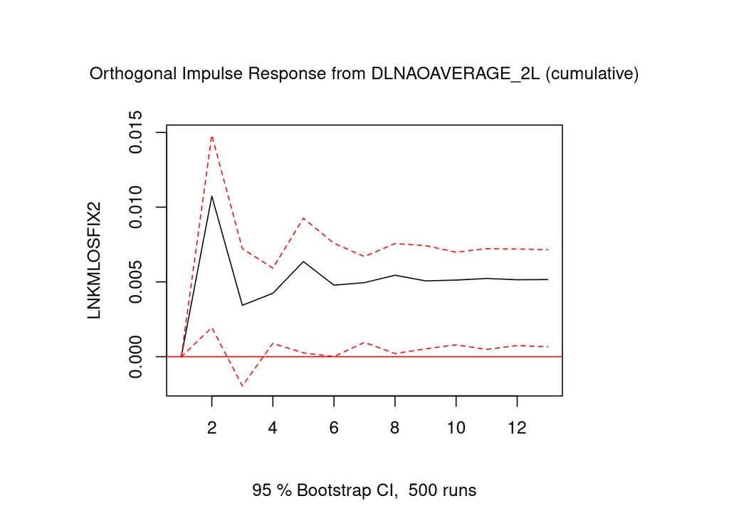

```r
railirf4 <- irf(railest, impulse = NULL, response = "LNKMLOSFIX2", n.ahead = 12,
               ortho = TRUE, cumulative = TRUE, boot = TRUE, ci = 0.95,
               runs = 500)
plot(railirf4)
```

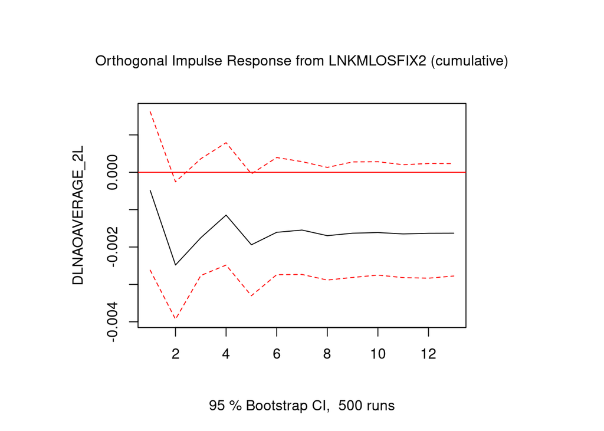

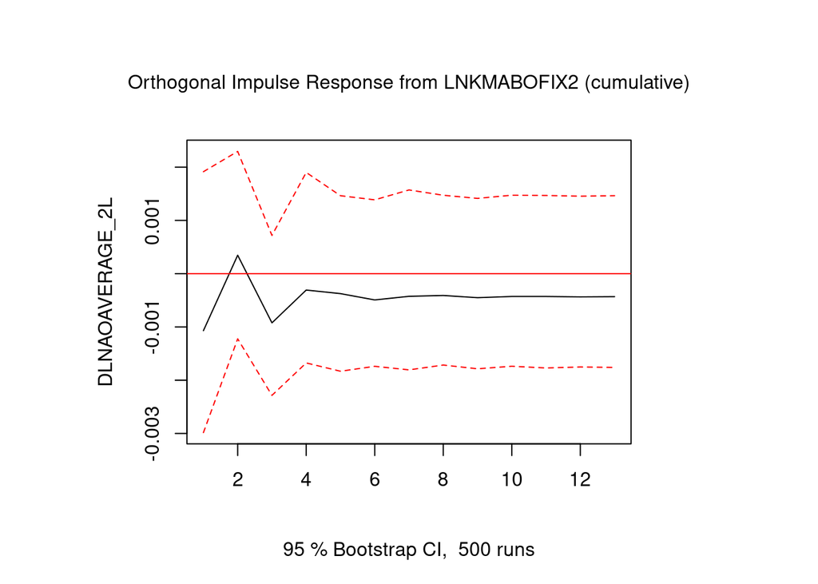

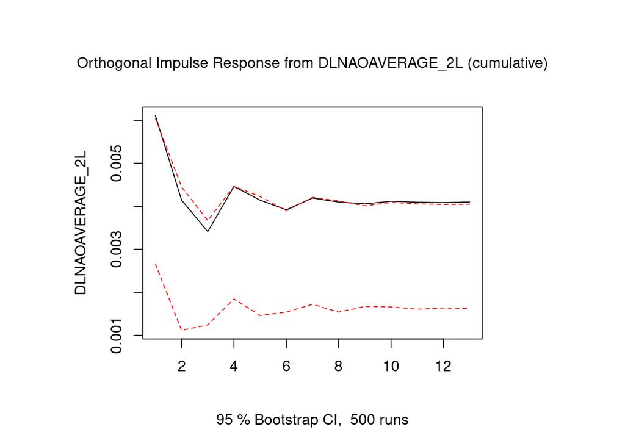

```r
railirf5 <- irf(railest, impulse = NULL, response = "DLNAOAVERAGE_2L", n.ahead = 12,
                ortho = TRUE, cumulative = TRUE, boot = TRUE, ci = 0.95,
                runs = 500)
plot(railirf5)
```

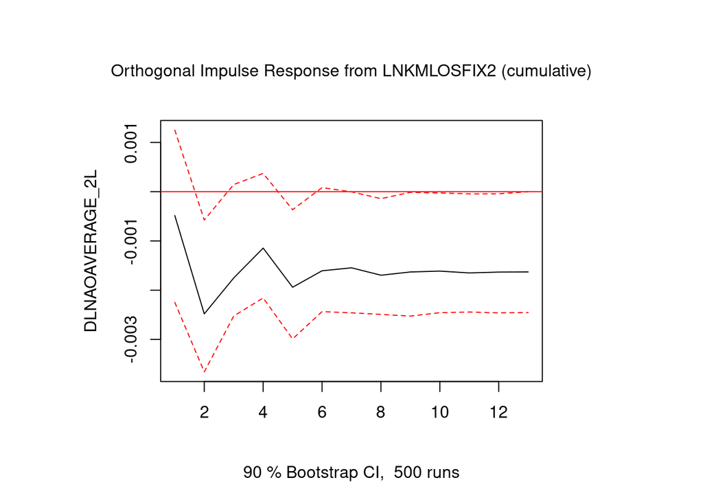

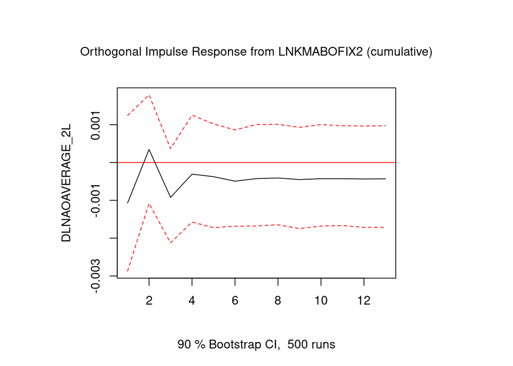

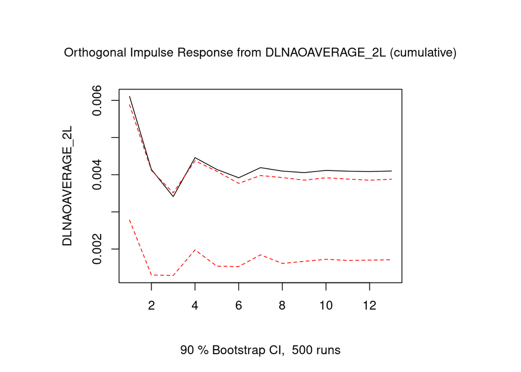

```r
railirf6 <- irf(railest, impulse = NULL, response = "DLNAOAVERAGE_2L", n.ahead = 12,
                ortho = TRUE, cumulative = TRUE, boot = TRUE, ci = 0.90,
                runs = 500)
plot(railirf6)
```